# Sampling a Population

Website Version

Author

Affiliation

Jon Yearsley

School of Biology and Environmental Science, UCD

Published

May, 2026

**TipHow to Read this Tutorial**

This tutorial is a mixture of R code chunks and explanations of the code. The R code chunks will appear in boxes.

Below is an example of a chunk of R code:

```r
# This is a chunk of R code. All text after a # symbol is a comment
# Set working directory using setwd() function
setwd('Enter the path to my working directory')

# Clear all variables in R's memory
rm(list=ls())    # Standard code to clear R's memory
```

Sometimes the output from running this R code will be displayed after the chunk of code.

Here is a chunk of code followed by the R output

```r
2 + 4            # Use R to add two numbers
```

```
[1] 6
```

# Objectives

The objectives of this tutorial are:

1. Distinguish between the concepts of a sample and a population
2. Introduce the concept of estimation and uncertainty in an estimate
3. Explain the approach of bootstrapping to estimate a standard error
4. Compare bootstrapping with classical statistical theory

# Introduction

This tutorial looks at the use of a representative **sample** to infer the central tendency of the **population** from which the sample was taken.

We will look at the human height data from the HEIGHT.CSV data file. To start with we will import the data from the HEIGHT.CSV file and extract just the data for women from 2010 and 2011.

```r
human <- read.table('HEIGHT.CSV', header=T, sep=',') # Import human height data set

# Extract data for all females
humanF <- subset(human, SEX=='Female')

# Extract data for females collected in 2010
humanF_2010 <- subset(human, SEX=='Female' & YEAR==2010)

# Extract data for females collected in 2011
humanF_2011 <- subset(human, SEX=='Female' & YEAR==2011)
```

# Before you continue:

Review this online lesson about sample and population.

**NoteOnline Lesson**

[Sample and Population](https://DrJonYearsley.github.io/OnlineLessons/lesson2_samplepopulation_Website.html)

This lesson is at https://DrJonYearsley.github.io/OnlineLessons/lesson2_samplepopulation_Website.html

# Population versus sample

To recap:

- The topic of the question is called **the population** and the data collected to answer the question is called **the sample**.
- A sample rarely contains all the objects in a population. Therefore, the data you have available has information missing about the population (i.e. the objects for which you don’t have data).

The difference between a population and a sample is fundamental to understand if you want to use data to reliably say something about the world.

Data analysis is all about using a sample (partial data about the population) to make **reliable** statements about the population.

## The average height of a female US army recruit

Lets think about the concrete example of the HEIGHT.CSV data set.

Say we want to answer the question:

> What is the mean height of female US army recruits?

> > **The population**  
> > The population is the set of heights of **all women** who have joined the US army.

> > **The sample**  
> > We’ll use the data from 2010 (dataframe `humanF_2010`) as a sample. These data comprise 116 height measurements of army recruits. Whilst this is a decent amount of data it is still a small fraction of all the female recruits who have ever joined the US army.

The sample gives us **partial information** about the population.

## Estimating the mean of a population

If you had to guess how to estimate the mean of a population you may try using the mean of the sample. Congratulations! This would be a great guess. There is even statistical theory that supports using the mean of a sample.

Using the mean of our sample from 2010 gives us an answer to the question above:

> **Female US army recruits are 1.628 m tall on average.**

But… we could have used the data from 2011 as the sample (dataframe `humanF_2011`).

Using the mean of data from 2011 gives us another answer to the question above:

> **Female US army recruits are 1.632 m tall on average.**

We have two different answers! Which is the right answer?

The answer is that both answers are correct, allowing for some **uncertainty**.

## Estimating uncertainty in the mean

Our estimates of the population mean have some uncertainty because the sample only gives **partial information** about the population.

To quantify the uncertainty in the estimated mean of the population mean we could

1. take several samples from the population,
2. calculate the mean of each sample
3. calculate the spread of these means. This spread will be a measure of uncertainty. Two common measures of uncertainty are:
   - the **standard error of the mean**: the standard deviation of the estimated means
   - the **95% confidence interval**: the 2.5% and 97.5% quantiles of the estimated means

There’s a problem: sampling the population several times is nearly always going to be impractical and costly.

Thankfully there are solutions. Two possibilities are

- bootstrapping
- statistical modelling of the population

Below we introduce bootstrapping. In later tutorials we will present statistical modelling.

## Bootstrapping

Bootstrapping is a very powerful technique that was originally proposed by Efron (1979). The idea is very simple: rather than resampling the population you resample the data you have, and then calculate the uncertainty in the means from these resamples. This approach turns out to be surprisingly good.

**TipBootstrapping**

```
Bootstrap algorithm to estimate the uncertainty in a population's mean
===================================================

1. Resample the data set with replacement
2. Calculate the mean of the resampled data
3. Repeat steps 1 and 2 many times (e.g. 1000 times)
4. The standard deviation of the reampled means is an estimate of the standard error of the mean
```

Aside: There are several variation on the bootstrapping algorithm. The above algorithm is the percentile method. Puth *et al.* (2015) discuss the different bootstrap algorithms commonly used.

One way to bootstrap in R is to use the `sample()` function.

```r
# Resample (with replacement) the numbers 1 to 10
sample(c(1:10), replace=TRUE)
```

```
 [1]  3  3  2 10  8  1 10  7  9  9
```

There are 10 numbers that we are sampling . This `sample()` command generates a new set of 10 numbers by randomly picking values from the original data. The `replace=TRUE` argument means that a single observation can be picked more than once (you can see that some numbers appear more than once in the resampled data). This is very important. Without the `replace=TRUE` your resample would be the same as the original data, which we don’t want.

```r
# Resample (without replacement) the numbers 1 to 10
sample(c(1:10), replace=FALSE)
```

```
 [1]  9  7  2  1 10  8  5  3  6  4
```

We can use this `sample()` command to generate a simple bootstrap estimate for the uncertainty in estimating the population mean. We will resample the 2010 data 10000 times.

```r
# Code to perform a simple bootstrap for an estimate of the mean of a population

# Create a variable that will contain the means of the resampled data
resample_mean2010 <- array(NA, dim=10000)

# Use a for loop to resample the data 10000 times using 2010 data
for (i in 1:10000) {
  resample <- sample(humanF_2010$HEIGHT, replace=T)
  # Save the mean of the resampled data in the array
  resample_mean2010[i] <- mean(resample)
}

# Calculate the standard deviation of the resampled means
sd(resample_mean2010)
```

```
[1] 0.005511198
```

Our bootstrap estimate for the standard error of the mean is 0.0055 m. Using this result we can now say that:

> **Female US army recruits have an average height of 1.628m (se 0.006m).**

We can do the same for the sample from 2011, which gives

> **Female US army recruits have an average height of 1.632m (se 0.002m).**

Now that we’ve estimated the standard error of the mean for both means we can see that they are consistent to within the uncertainty.

**Tip**

As a rule of thumb: two estimates are consistent if the estimate’s uncertainties overlap (uncertainty must be measured by a 95% confidence interval or twice the standard error)

In this case, twice the standard error gives the ranges 1.617 - 1.639 m and 1.628 - 1.636 m. These two ranges overlap, indicating consistency in our estimates of the population.

### The Sampling Distribution

The **sampling distribution** is the distribution of means from repeatedly sampling a population. Our resampled means from the bootstrap give use an estimate of the sampling distribution. This sampling distribution can be visualise using a histogram.

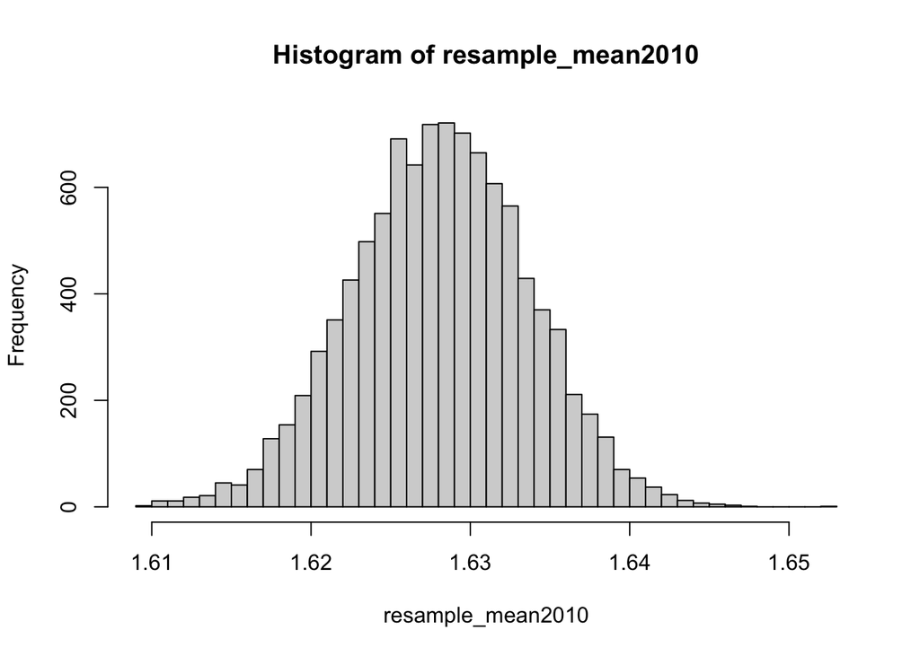

```r
# A histogram of the resampled means
hist(resample_mean2010, n=50)
```

In theory, bootstrapping should work for many quantities (e.g. median, standard deviation, quantiles) not just the mean. Bootstrapping can even work on unusual estimates, such as evolutionary trees, or genetic sequence data.

However, bootstrapping is not always appropriate. For example, it should not be used to estimate uncertainties on extreme values (e.g. the maximum and minimum).

A range of different bootstrapping approaches exist, but are beyond the scope of this tutorial. R has a couple of packages to perform boostrapping (e.g. the packages `boot` and `bootstrap`).

Bootstrapping is a very powerful tool.

# Summary of the topics covered

# Further Reading

All these books can be found in UCD’s library

- Graeme D. Ruxton and Nick Colegrave, 2010 **Experimental design for the life sciences**, 3rd ed (Oxford University Press, Oxford)
- Michael J. Crawley, 2015 **Statistics : an introduction using R** (John Wiley & Sons, Chichester) [Chapters 1, 5]
- Tenko Raykov and George A Marcoulides, 2013 **Basic statistics: an introduction with R** (Rowman and Littlefield, Plymouth) [Chapters 7, 8]
- John Verzani, 2005 **Using R for introductory statistics** (Chapman and Hall, London) [Chapter 5]

## References

Efron, B. 1979. “Bootstrap Methods: Another Look at the Jackknife.” *Ann. Statist.* 7 (1): 1–26. https://doi.org/10.1214/aos/1176344552.

Puth, Marie-Therese, Markus Neuhäuser, and Graeme D. Ruxton. 2015. “On the variety of methods for calculating confidence intervals by bootstrapping.” *Journal of Animal Ecology* 84 (4): 892–97. https://doi.org/10.1111/1365-2656.12382.